Independent research reproduction · arXiv:2608.07536v1

# Yield-curve reproduction

Original Treasury zero-coupon data, macro predictors, and direct versus factor forecasts.

Completed: 50 trees per forest

14 competing models + random walk · 4 horizons · 13 targets · 780 metric rows

**Scope:** The paper uses 500 trees. The supplied run uses 50. Data and baseline AR forecasts match at displayed precision; ML and trading results are independent reconstructions with documented assumptions.

## What matches the paper

| Check | Matches | Cells | Precision |
| --- | --- | --- | --- |
| Table 1 yield summary statistics | 78 | 78 | 3 decimals |
| Random-walk absolute RMSE | 52 | 52 | 2 decimals |
| DNS-AR relative RMSE | 52 | 52 | 2 decimals |
| DNSS-AR relative RMSE | 52 | 52 | 2 decimals |
| DNS-AR absolute RMSE | 52 | 52 | 2 decimals |
| DNSS-AR absolute RMSE | 52 | 52 | 2 decimals |

All comparisons use independently computed values beside numerical references extracted from the paper. Forecast origins run January 2015–May 2025; realized targets extend through June 2025. Sample sizes are 125, 123, 120, and 114 for the four horizons.

## Computed forecast results

Direct-RF-X has lower RMSE than Direct-RF in 12/12 slope/horizon comparisons in this run. These rankings reflect 50-tree forests and the stated ten-maturity information set. They do not establish that every headline result in the paper replicates.

Unweighted average relative RMSE across the forecast horizons and the targets within each segment. Below one beats the random walk.

| segment | model | Short end | Belly | Long end | Slope |
| --- | --- | --- | --- | --- | --- |
|  | Direct-RF-X | 0.912 | 1.015 | 1.055 | 0.970 |
|  | DNSS-RF-X | 1.000 | 1.086 | 1.182 | 1.027 |
|  | Direct-RF | 0.921 | 0.984 | 1.090 | 1.054 |
|  | DNSS-AR | 1.000 | 1.069 | 1.192 | 1.096 |
|  | DNSS-RF | 1.019 | 1.058 | 1.136 | 1.122 |
|  | DNSS-RF-fixedPSO-X | 1.055 | 1.131 | 1.262 | 1.173 |
|  | DNS-RF-X | 0.962 | 1.009 | 1.120 | 1.176 |
|  | DNSS-AR-fixedPSO | 0.985 | 0.947 | 0.959 | 1.221 |
|  | DNS-AR | 1.064 | 1.009 | 1.078 | 1.233 |
|  | DNSS-RF-fixedPSO | 1.118 | 1.160 | 1.221 | 1.234 |
|  | DNS-RF | 1.022 | 1.053 | 1.165 | 1.262 |
|  | DNSS-AR-PSO | 2.632 | 2.657 | 2.166 | 3.670 |
|  | DNSS-RF-PSO-X | 4.616 | 4.816 | 5.775 | 5.539 |
|  | DNSS-RF-PSO | 5.000 | 5.244 | 6.733 | 6.024 |

## Relative forecast error

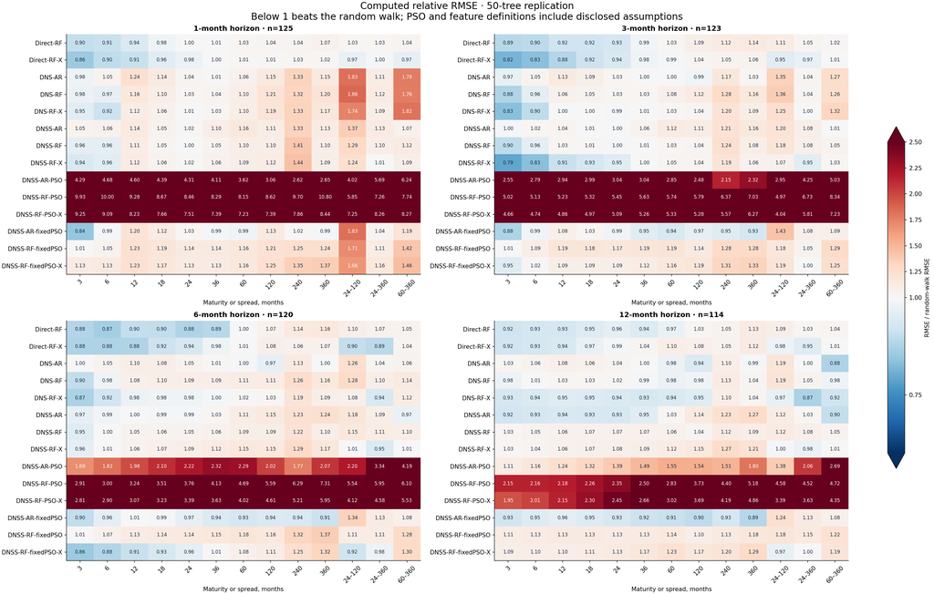

## Forecast paths

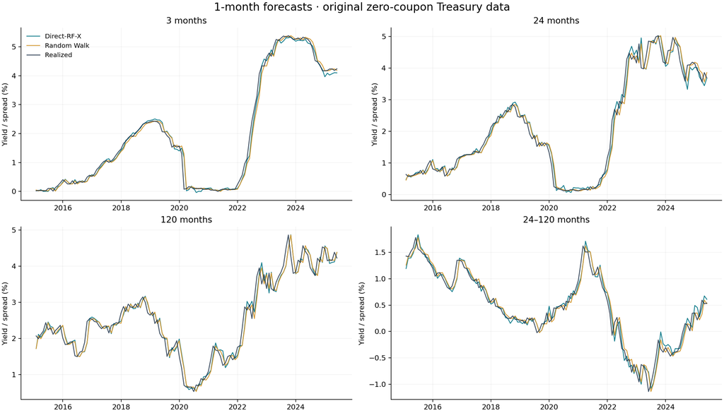

## Yield-curve data

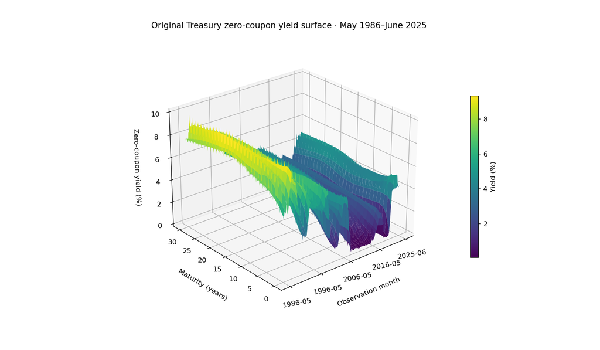

## Macro feature importance

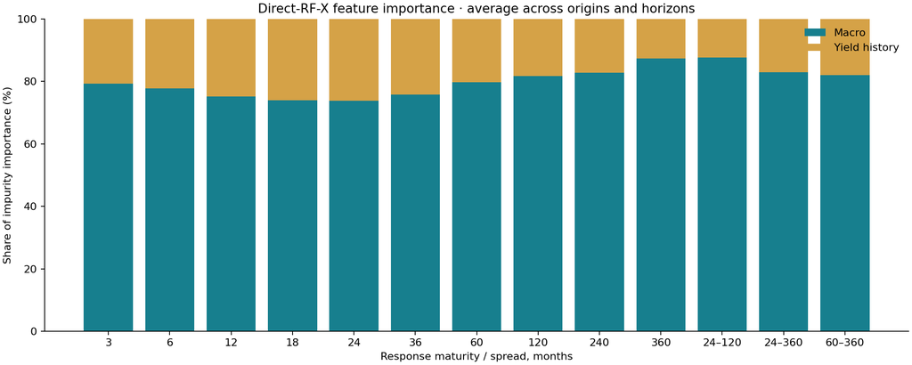

## Macro categories

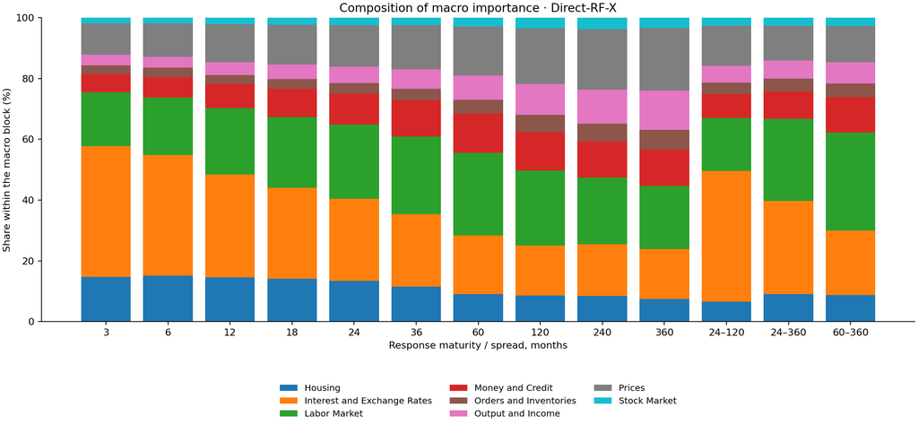

## Cross-sectional curve fit

Mean date-level RMSE over May 1986–June 2025, in percentage points. Pooled decays use the published 0.035/0.006 values. Time-varying optimization is sensitive to unspecified initialization and PSO settings.

| model | mean_cross_sectional_rmse_pp | paper_value | difference |
| --- | --- | --- | --- |
| DNS | 0.113945 | 0.114000 | -0.000055 |
| DNSS | 0.092287 | 0.092300 | -0.000013 |
| DNSS-fixedPSO | 0.069978 | — | — |
| DNSS-PSO | 0.025500 | 0.028400 | -0.002900 |
| DNSS-PSO-ZLB | 0.030611 | 0.033100 | -0.002489 |

**PSO forecasts did not replicate.** The time-varying model's forecasting errors are substantially larger than the paper reports, despite close curve fits. The primary run uses the unscaled objective and stated local tolerances. Unspecified optimizer settings and unstable factor identification remain unresolved.

The table below compares the primary objective with an explicit objective-scaling sensitivity. Scaling preserves the mathematical optimum but changes effective stopping tolerances. Values are mean relative RMSE across the 13 targets; the other core and fixed-decay models are unchanged.

| model | horizon | relative_rmse_unscaled | relative_rmse_scaled |
| --- | --- | --- | --- |
| DNSS-AR-PSO | 1 | 4.177 | 4.500 |
| DNSS-AR-PSO | 3 | 3.030 | 3.132 |
| DNSS-AR-PSO | 6 | 2.309 | 2.296 |
| DNSS-AR-PSO | 12 | 1.556 | 1.624 |
| DNSS-RF-PSO | 1 | 8.671 | 10.710 |
| DNSS-RF-PSO | 3 | 5.904 | 7.040 |
| DNSS-RF-PSO | 6 | 4.770 | 6.938 |
| DNSS-RF-PSO | 12 | 3.351 | 4.463 |
| DNSS-RF-PSO-X | 1 | 7.987 | 9.808 |
| DNSS-RF-PSO-X | 3 | 5.317 | 5.897 |
| DNSS-RF-PSO-X | 6 | 4.080 | 4.881 |
| DNSS-RF-PSO-X | 12 | 3.127 | 3.761 |

## Trading reconstruction

The exercise prices synthetic zero-coupon bonds at entry and their shorter remaining maturities at exit. Slope positions are DV01-neutral at entry and gross-value normalized. Costs are one basis point each way. Signal scaling uses 24 pre-evaluation months.

Longer-horizon holding periods overlap. Annualized returns below are arithmetic mean holding-period returns multiplied by 12/h; they are not a compounded wealth path. The paper does not fully specify its capital normalization, so these trading numbers are not claimed to reproduce its tables.

| model | trade_type | average_rank_total | average_rank_curve | annual_return_pct | annual_curve_move_net_pct | annual_roll_down_pct | hit_rate |
| --- | --- | --- | --- | --- | --- | --- | --- |
| DNSS-AR-fixedPSO | duration | 3.667 | 3.750 | 3.188 | 3.776 | -0.588 | 0.598 |
| DNS-AR | duration | 4.000 | 7.083 | 2.251 | 1.862 | 0.390 | 0.581 |
| Random Walk | duration | 4.917 | 14.917 | 0.368 | -2.110 | 2.477 | 0.566 |
| Roll-down | duration | 5.083 | 14.583 | 0.367 | -2.108 | 2.475 | 0.566 |
| DNSS-RF | duration | 7.000 | 6.167 | 0.725 | 1.406 | -0.681 | 0.495 |
| DNS-RF-X | duration | 7.333 | 5.833 | 0.451 | 0.566 | -0.115 | 0.533 |
| DNSS-AR | duration | 8.583 | 5.167 | 0.674 | 2.176 | -1.502 | 0.504 |
| DNSS-AR-PSO | duration | 9.000 | 6.083 | 0.469 | 1.031 | -0.562 | 0.476 |
| DNS-RF | duration | 10.250 | 9.667 | -0.677 | -0.371 | -0.305 | 0.522 |
| TSMOM | duration | 10.333 | 7.333 | -0.335 | 0.101 | -0.436 | 0.501 |
| DNSS-RF-fixedPSO-X | duration | 10.833 | 9.000 | -1.537 | -1.286 | -0.252 | 0.465 |
| DNSS-RF-fixedPSO | duration | 10.917 | 10.417 | -0.477 | -0.360 | -0.118 | 0.481 |
| DNSS-RF-X | duration | 11.083 | 9.833 | -0.967 | -0.635 | -0.332 | 0.473 |
| DNSS-RF-PSO-X | duration | 11.750 | 10.833 | -1.019 | -0.733 | -0.286 | 0.491 |
| Direct-RF-X | duration | 12.250 | 10.000 | -1.574 | -1.214 | -0.361 | 0.468 |
| DNSS-RF-PSO | duration | 12.583 | 11.583 | -1.499 | -0.998 | -0.501 | 0.476 |
| Direct-RF | duration | 12.750 | 10.083 | -2.458 | -1.808 | -0.650 | 0.474 |
| DNSS-AR | slope | 2.000 | 10.583 | 1.071 | 0.028 | 1.043 | 0.674 |
| Roll-down | slope | 3.083 | 14.750 | 1.192 | -0.411 | 1.603 | 0.679 |
| DNSS-AR-fixedPSO | slope | 3.750 | 12.333 | 0.859 | -0.142 | 1.002 | 0.685 |
| DNS-AR | slope | 5.750 | 10.167 | 0.703 | 0.088 | 0.615 | 0.627 |
| DNS-RF-X | slope | 7.083 | 4.500 | 0.492 | 0.478 | 0.015 | 0.534 |
| DNSS-RF-X | slope | 7.750 | 3.583 | 0.494 | 0.455 | 0.039 | 0.510 |
| DNS-RF | slope | 8.000 | 7.417 | 0.446 | 0.226 | 0.220 | 0.534 |
| DNSS-RF-fixedPSO-X | slope | 8.250 | 3.833 | 0.400 | 0.433 | -0.032 | 0.528 |
| Direct-RF-X | slope | 8.500 | 1.917 | 0.547 | 0.697 | -0.149 | 0.519 |
| DNSS-RF | slope | 8.750 | 8.083 | 0.414 | 0.122 | 0.292 | 0.500 |
| DNSS-RF-fixedPSO | slope | 8.917 | 5.917 | 0.408 | 0.284 | 0.124 | 0.551 |
| Direct-RF | slope | 9.667 | 6.583 | 0.309 | 0.265 | 0.043 | 0.501 |
| DNSS-RF-PSO-X | slope | 11.500 | 8.667 | 0.128 | 0.051 | 0.077 | 0.553 |
| DNSS-RF-PSO | slope | 12.333 | 11.917 | -0.015 | -0.129 | 0.114 | 0.541 |
| DNSS-AR-PSO | slope | 14.667 | 9.750 | -0.417 | 0.032 | -0.449 | 0.431 |

## Why exact ML reproduction remains unresolved

- The stated ten maturities create 60 yield predictors; Table 4 reports 90 without identifying the other series.
- Appendix A contains 125 codes but the text says 123. Two listed codes do not occur in the source files; those exclusions are logged.
- The macro vintage, missing-value treatment, random seeds, pooled-PSO tuning, and several backtest conventions are unspecified.
- Appendix A's codes 3/6/7 differ from official FRED-MD transformations. Both conventions are implemented. Revised-data publication lags do not remove revision look-ahead.

The full choices and their justification are in `references/REPRODUCTION_DECISIONS.md`. Original inputs, configuration, package versions, source hashes, and training dates are retained.

## Run the 500-tree experiment

```
python -m pip install -r requirements.txt
python run.py --config configs/full_500_trees.json --output results/full_500 --workers 8
python make_report.py --results results/full_500
```

The full settings can take several hours. Each completed model/horizon job is checkpointed. Scientific checks cover factor recovery, forecast-label availability, publication lags, training-only imputation, transformation differences, HAC lag selection, bond ageing, and hedge neutrality.

Use `reproduction.ipynb` to explore the supplied tables. Each experiment has separate numerical forecasts, model comparisons, feature importances, trading diagnostics, and a provenance manifest.